# Dominica: Summary of fisheries landings and value from publicly available data

2023-03-07

## Introduction

This document provides a brief summary of Dominica’s fisheries landings and value from publicly available datasets. This document largely draws upon landings data from the [FAO global capture production database](https://www.fao.org/fishery/statistics-query/en/capture/capture_quantity) and the [Sea Around Us (SAU) database of reconstructed fisheries catches](https://www.seaaroundus.org/data/#/eez/212?chart=catch-chart&dimension=taxon&measure=tonnage&limit=10).

## Reported landings

Capture fisheries production reported to the FAO is available for Dominica between 1950 to 2019. Total capture production in 2019 was reported to be 783 mt.

Though inland (freshwater) production is reported of “Freshwater fishes nei”, its magnitude is negligible (less than 1 mt per year) and thus appears as a zero in the FAO database. Therefore, marine production makes up the entirety of Dominica’s reported capture production from the FAO database.

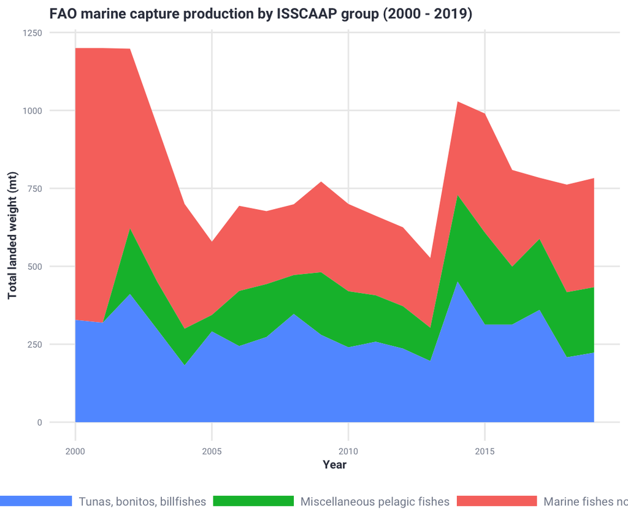

Total fisheries landings for Dominica by ISSCAAP group from FAO (2000 - 2019).

Landings for the following species (or species categories) are reported: Atlantic bonito, Atlantic sailfish, Bigeye tuna, Blackfin tuna, Blue marlin, Common dolphinfish, King mackerel, Longbill spearfish, Marine fishes nei, Skipjack tuna, Swordfish, Tuna-like fishes nei, Wahoo, Yellowfin tuna.

[figure not shown]

Total fisheries landings for Dominica by species from FAO (2000 - 2019).

### Estimated value

FAO does not report the value of capture production directly, but we can estimate the value of Dominica’s reported catches using global price datasets from literature. Melnychuk et al. (2016) created a reconstructed database of global ex-vessel prices for fished species between 1976 and 2012. Researchers at the Environmental Markets Lab (emLab) at UCSB updated this database in 2021 such that it includes reconstructed prices from 1976 - 2019.

Reconstructed prices (US$/mt) for species caught in Dominica (2010 - 2019). Sources: Melnychuk et al. (2016) and the Environmental Markets Lab.

| Species | Scientific name | 2010 | 2011 | 2012 | 2013 | 2014 | 2015 | 2016 | 2017 | 2018 | 2019 |
| --- | --- | --- | --- | --- | --- | --- | --- | --- | --- | --- | --- |
| Atlantic bonito | Sarda sarda | $1,929 | $2,038 | $1,614 | $1,636 | $2,159 | $1,876 | $1,965 | $2,277 | $2,508 | $2,201 |
| Atlantic sailfish | Istiophorus albicans | $2,228 | $2,677 | $1,809 | $958 | $736 | $876 | $929 | $1,034 | $1,051 | $1,903 |
| Bigeye tuna | Thunnus obesus | $2,564 | $4,978 | $4,239 | $2,242 | $2,317 | $2,272 | $2,565 | $2,605 | $2,515 | $2,313 |
| Blackfin tuna | Thunnus atlanticus | $3,025 | $3,299 | $3,139 | $2,247 | $2,106 | $2,037 | $2,395 | $2,533 | $2,538 | $2,535 |
| Blue marlin | Makaira nigricans | $2,228 | $2,677 | $1,809 | $958 | $736 | $876 | $929 | $1,034 | $1,051 | $1,903 |
| Common dolphinfish | Coryphaena hippurus | $1,531 | $1,740 | $1,301 | $1,395 | $1,790 | $2,460 | $2,448 | $3,806 | $2,502 | $2,994 |
| Finfishes nei | Osteichthyes | $637 | $676 | $688 | $1,346 | $1,297 | $1,197 | $1,346 | $1,395 | $1,554 | $1,495 |
| Freshwater fishes nei | Osteichthyes | $998 | $862 | $1,020 | $1,424 | $1,069 | $1,079 | $1,242 | $1,141 | $1,286 | $1,387 |
| Groundfishes nei | Osteichthyes | $1,088 | $1,112 | $1,199 | $1,602 | $1,714 | $1,703 | $1,386 | $1,756 | $1,804 | $1,999 |
| King mackerel | Scomberomorus cavalla | $648 | $978 | $2,351 | $1,707 | $1,237 | $1,517 | $1,652 | $1,804 | $1,875 | $1,452 |
| Longbill spearfish | Tetrapturus pfluegeri | $2,228 | $2,677 | $1,809 | $958 | $736 | $876 | $929 | $1,034 | $1,051 | $1,903 |
| Marine fishes nei | Osteichthyes | $637 | $676 | $688 | $1,346 | $1,297 | $1,197 | $1,346 | $1,395 | $1,554 | $1,495 |
| Pelagic fishes nei | Osteichthyes | $1,154 | $1,030 | $1,189 | $1,390 | $1,696 | $1,379 | $1,371 | $2,150 | $2,307 | $2,286 |
| Skipjack tuna | Katsuwonus pelamis | $982 | $1,060 | $1,433 | $999 | $790 | $938 | $1,216 | $1,487 | $1,384 | $1,241 |
| Swordfish | Xiphias gladius | $5,055 | $5,332 | $4,256 | $2,615 | $2,837 | $2,881 | $3,425 | $3,487 | $3,346 | $3,347 |
| Tuna-like fishes nei | Scombroidei | $3,987 | $4,002 | $3,451 | $2,698 | $2,473 | $2,286 | $2,614 | $2,749 | $2,627 | $2,505 |
| Wahoo | Acanthocybium solandri | $3,987 | $4,002 | $3,451 | $2,698 | $2,473 | $2,286 | $2,614 | $2,749 | $2,627 | $2,505 |
| Yellowfin tuna | Thunnus albacares | $1,788 | $2,389 | $2,001 | $1,389 | $1,280 | $1,180 | $1,338 | $1,487 | $1,465 | $1,446 |

Matching this back to the FAO marine production data estimates total landed value between US$1,387,800 and US$3,957,584 annually between 2000 and 2019.

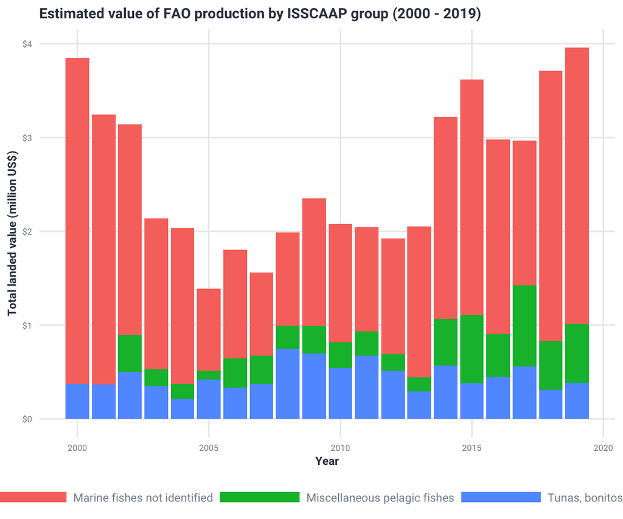

Estimated value by ISSCAAP group for Dominican fisheries from FAO (2000 - 2019).

## Reconstructed landings

SAU reconstructed catch data is available for Dominica between 1950 to 2019. Total capture production in 2019 was reported to be 1854 mt. Landings for the following species (or species categories) are reconstructed: Albacore, Atlantic bluefin tuna, Atlantic bonito, Atlantic sailfish, Atlantic thread herring, Atlantic white marlin, Ballyhoo halfbeak, Bigeye tuna, Billfishes, Blackfin tuna, Blue marlin, Blue runner, Blue shark, Caribbean spiny lobster, Cero, Common dolphinfish, Common pencil squids, Crevalle jack, Eels, morays, Escolar, Flatfishes, Frigate tuna, Goatfishes, Great barracuda, Greater amberjack, Grunts, sweetlips, bonnetmouths, Herrings, sardines, menhadens, Herrings, shads, anchovies, Jacks, Jacks, pompanos, King mackerel, Little tunny, Longbill spearfish, Mackerels, tunas, bonitos, Marine fishes nei, Mojarras, silverbellies, Oceanic whitetip shark, Octopuses, argonauts, Oilfish, Pelagic fishes, Perch-likes, Porgies, Porgies, seabreams, Red grouper, Requiem sharks, Round sardinella, Seabasses, hinds, Sharks, rays, chimaeras, Sharks, rays, skates, Shortfin mako, Shrimps and prawns, Silky shark, Skipjack tuna, Snappers, Southern red snapper, Spanish mackerels, Squids, Squirrel-, soldierfishes, Surgeons, tangs, unicornfishes, Swordfish, Swordfishes, Thresher, Triggerfishes, Tunas, Wahoo, Whiptail stingrays, Yellowfin tuna, Yellowtail snapper.

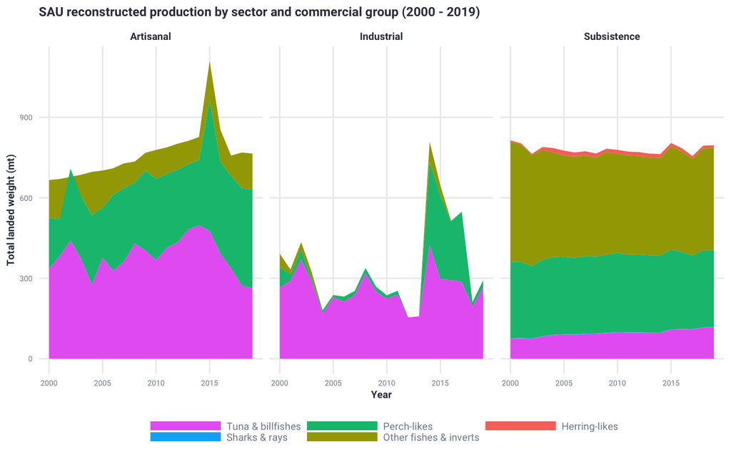

Total fisheries landings for Dominica by sector and commercial group from SAU (2000 - 2019).

The fishing sector breakdown used by SAU (across all countries) unfortunately does NOT match up well with how Dominica internally defines its fleets. From their report on how they reconstructed Dominica’s catches, Ramdeen et al. (2014) even recognizes that nearly all of the fisheries in Dominica are artisanal (a statement repeated by Theophile, 2015), but they define some of the reconstructed catches as “industrial” and “subsistence” anyways. Ramdeen et al. (2014) state: “The artisanal sector consists predominantly of part-time fishers who operate from motorized vessels, including dugout canoes up to 6 m in length, “keel” boats which range from 4-7 m and fiber reinforced plastic vessels. This fishery is seasonal, with a high season from January to June when pelagic species such as flying fish (Exocotidae), tuna (Thunnus spp.), dolphinfish (Corryphaena hippurus) and kingfish (Scomberomorus cavalla) are targeted with trolling, gillnets, hand lines and beach seines, and a low season from July to December, when demersal species are targeted with handlines and fish pots.”

It is worth noting that the SAU reconstructions do not include catches made by French fishers (from Guadeloupe and Martinique) - likely on the Macouba bank. Ramdeen et al. (2014) note that such activity has been documented, but data on the effort and landings of these fishers were not available.

### Estimated value

SAU estimate the value of their reconstructed catches directly. Total landed value was estimated between US$3,729,477 and US$6,531,229 annually between 2000 and 2019.

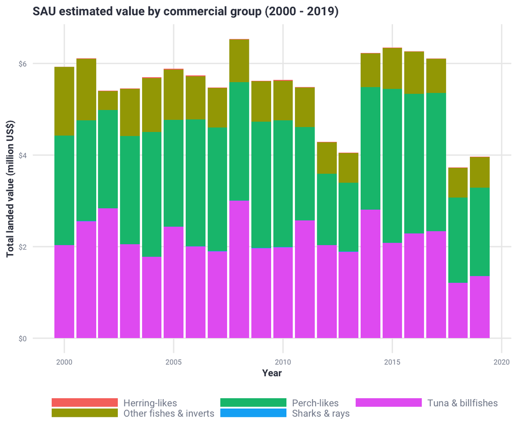

Estimated value by commerical group for Dominican fisheries from SAU (2000 - 2019).

## Comparison

In their analysis of Dominica’s fisheries data, Theophile (2015) found total landings calculated from national data to be higher than the values reported to the FAO between 1994 and 2013, especially for the period from 2005-2013. Unsurprisingly, both the national landings and FAO data were lower than the reconstructed values done by SAU (Ramdeen et al., 2014).

### Catches

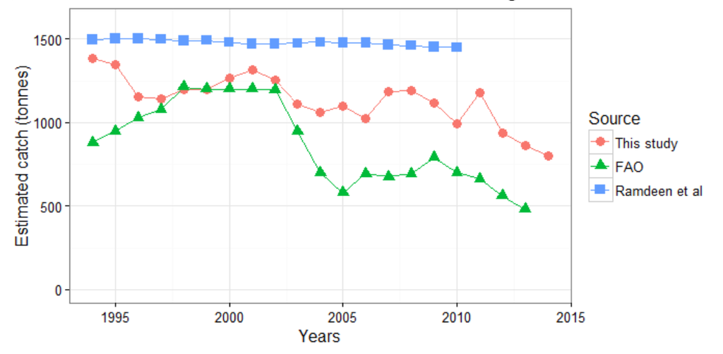

Comparison between total fisheries landings for Dominica from different sources. Source: Fig. 9 from Theophile (2015).

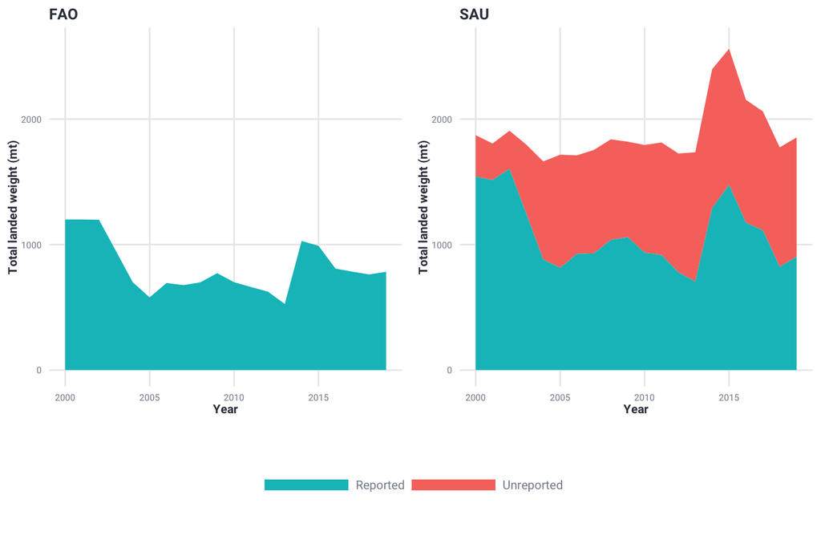

Comparison between total fisheries landings for Dominica from SAU and FAO (2000-2019).

### Value

Interestingly, even though the reconstructed catches from SAU are much higher than the reported values, the estimated value from SAU does not differ as significantly from that reported in Theophile (2015). The estimated value of the FAO landings are quite a bit lower starting around 2000 though.

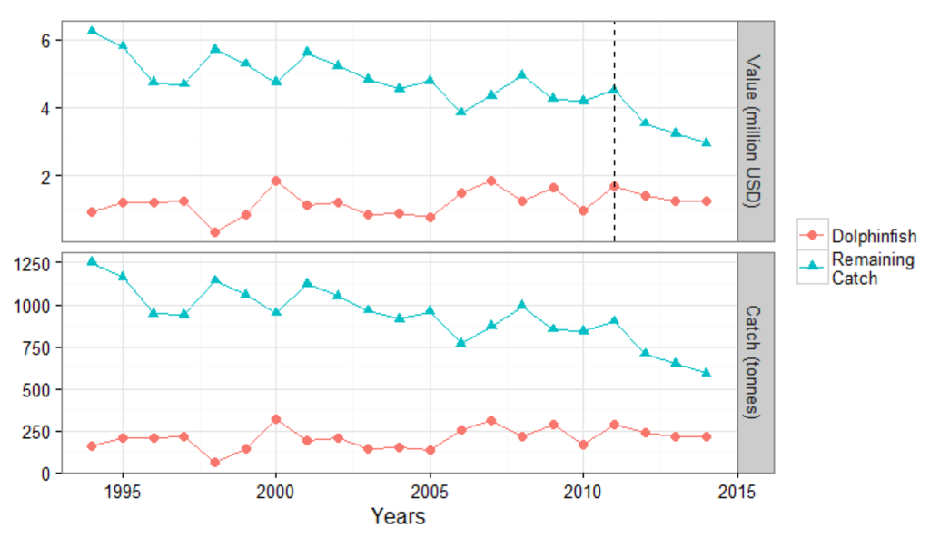

Catches and value of dolphinfish and other species in Dominica (1995 - 2014). Source: Fig. 14 from Theophile (2015).

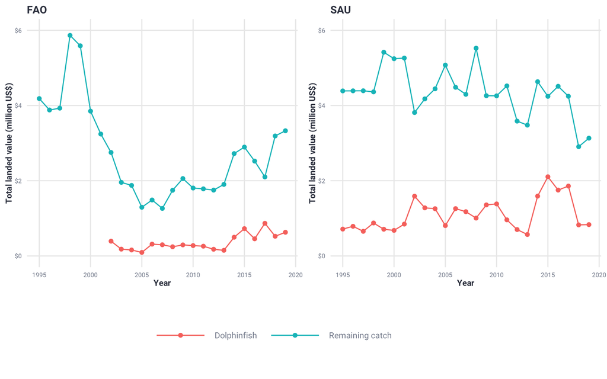

Estimated value of dolphinfish and other species’s catches in Dominica from SAU and FAO (1995 - 2019).

## Recommendations

### Catch data

Neither source of data allows for direct analysis of catches at the fleet/fishery level that Dominica seems to define internally (i.e., nearshore vs. offshore). However, from the discussion of fishing methods used (and species types caught) by each fleet from Theophile (2015), we can make some assumptions regarding the FAO data to this effect:

- It is likely that most of the catches from the older fishers who work the traditional dug-out canoes (operating within five miles or 8 km from the coast) are being lumped into the “Marine fishes nei” category. Theophile noted that this fleet uses nets deployed from the canoes to target small coastal pelagics such as ballyhoo (Hemiramphus brasiliensis), jacks (Carangidae) or mackerels (Scombridae). This fleet also uses fish pots or traps to fish for demersals such as snappers (Etelis and Lutjanus) or groupers (Epinephelus and Mycteroperca).
- It is likely that most of the landings of the other species types reported by the FAO are coming from the younger fishers (operating up to 80 miles or 129 km offshore) using keel or fibre-reinforced plastic (FRP) vessels (also known as pirogues). Theophile (2015) noted that this fleet catches small coastal pelagics, large migratory (ocean) pelagics, and demersals with an assortment of fishing gear and methods (fish pots, hook and line and nets). The most commercially important large pelagics for this fleet are dolphin fish (Coryphaena hippurus), yellowfin tuna (Thunnus albacares) and blue marlin (Makaira nigricans). Hook and line gear/methods are the most commonly used on these types of vessels, sometimes in conjunction with Fish Aggregating Devices (FADs).

Similar disaggregation by species or species types could probably done with the SAU data, but as mentioned above, I would not try to use the fishing sector breakdown (industrial/artisanal/subsistence) from SAU directly.

### Price data

Information on local ex-vessel prices seems to be really lacking in the public domain for Dominica.

- **I would focus a lot of attention on trying to obtain this information, if it exists. From Juan’s information, there are seemingly three prices/market avenues to collect data on: 1) fish sold directly by cooperatives, 2) fish sold by fishers/the ladies’ association on the side of the road, 3) fish sold directly by fishers to hotels.**

Additionally, because prices of pelagics (dolphinfish, tunas, marlins, etc.) tend to be more consistent globally, and because the catches likely to belong to the offshore (younger) fleet are better defined to the species level in the publicly available data, I have more confidence in the value estimates pertaining to this fishery. I think this is consistent with Juan’s belief that this fishery receives most of the attention.

- **I think it would be worthwhile to focus data-collection efforts on the nearshore (older) fishery because less seems to be known about it, but the magnitude of catches are quite large. I would try to obtain better (i.e., species level) data pertaining to the nearshore (older) fleet from Derrick, if it exists. I think this is where you could find the greatest differences in estimated value between the official and publicly available data. I think the value associated with this fleet is also likely to be your greatest source of uncertainty as a lot of the catch may go toward personal/family consumption and therefore be more difficult to value.**

### Other

- **I would not focus too heavily on trying to obtain data on prices of exported products because these aren’t going to contribute to much of the total value.**

## References

Melnychuk, M. C., Clavelle, T., Owashi, B., & Strauss, K. (2016). Reconstruction of global ex-vessel prices of fished species. ICES Journal of Marine Science, 74(1), 121–133. https://doi.org/10.1093/icesjms/fsw169

Ramdeen, R., Harper, S., & Zeller, D. (2014). Reconstruction of Total Marine Fisheries Catches for Dominica (1950-2010) (p. 9).

Theophille, D. (2015). COLLECTION, MANAGEMENT AND PRIMARY ANALYSIS OF FISHERIES DATA IN THE COMMONWEALTH OF DOMINICA.